# Practicando clustering:

Pasos previos:

- Descargue las puntuaciones de felicidad de cada país de este link: https://en.wikipedia.org/wiki/World_Happiness_Report
- Descargue las puntuaciones de democracia de cada país de este link: https://en.wikipedia.org/wiki/Democracy_Index
- Todos las columnas que forman ambos indices se usarán. Si desea quédese con lo indispensable:
- Una ambas tablas.
- Verifique que tiene los datos listos para aplicar la tecnica de clusterizacion.
- Prepare los datos para el analisis cluster, use como semilla aleatoria al numero **123**.
- Calcule 3 clusters usando la técnica de pam(k-medoides) y la jerarquica aglomerativa:

### Responda:

1. ¿Se debió obtener 3 clusters usando k-medoides, u otro valor era mejor?

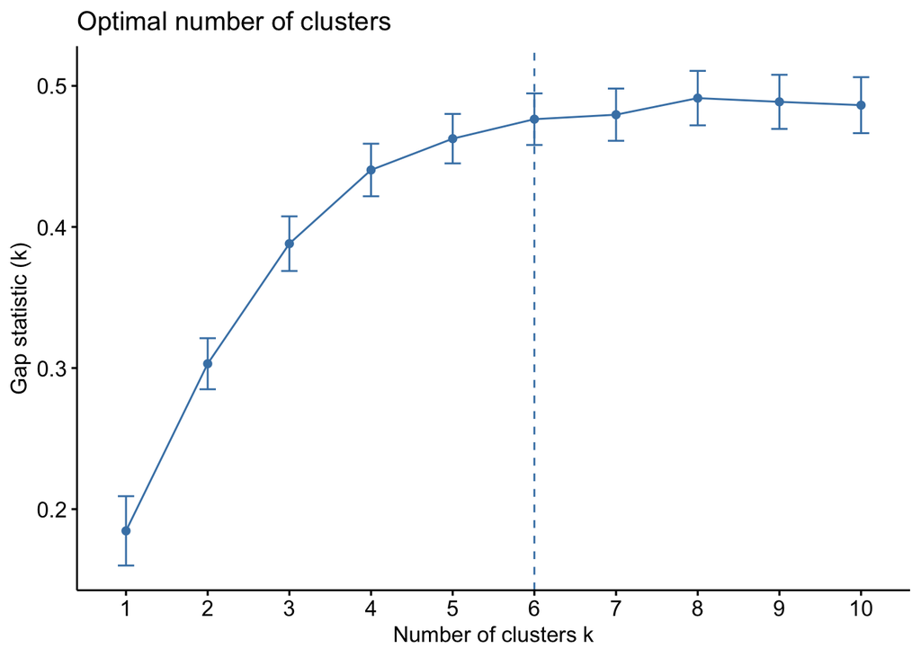

2. ¿Se debió obtener 3 clusters usando jerarquizacion aglomerativa, u otro valor era mejor?

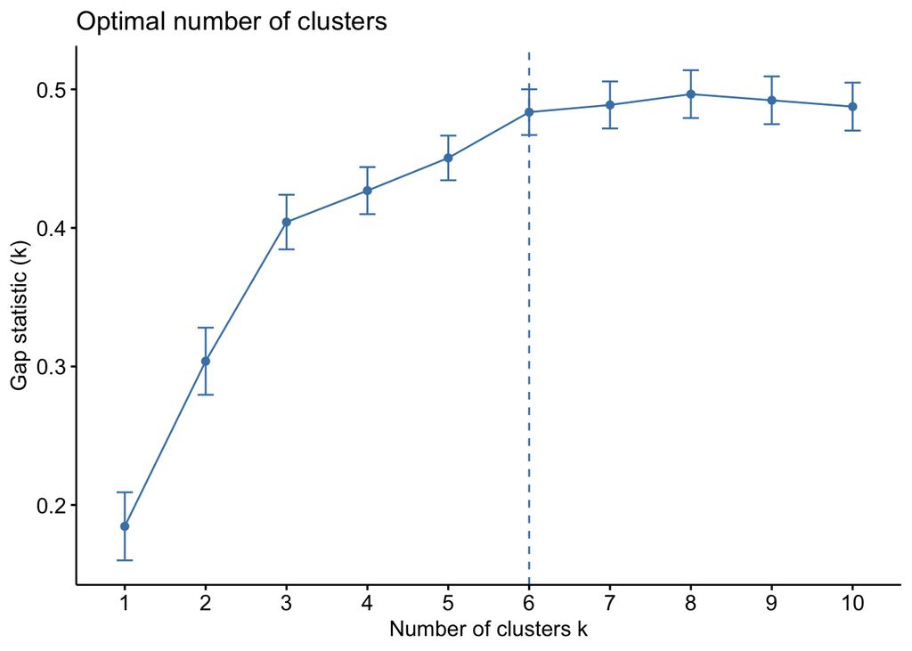

3. Si se mantiene pedir tres clusters en ambos procedimientos ¿Cuál clusterizó mejor?

```
##   cluster size ave.sil.width
## 1       1   58          0.25
## 2       2   59          0.29
## 3       3   30          0.42
```

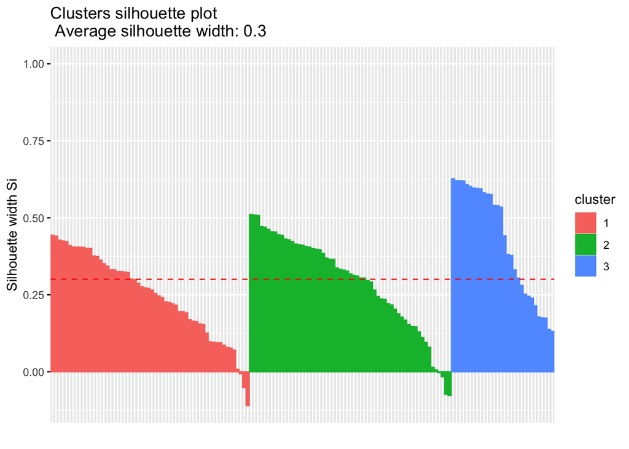

```
##   cluster size ave.sil.width
## 1       1   49          0.31
## 2       2   80          0.22
## 3       3   18          0.60
```

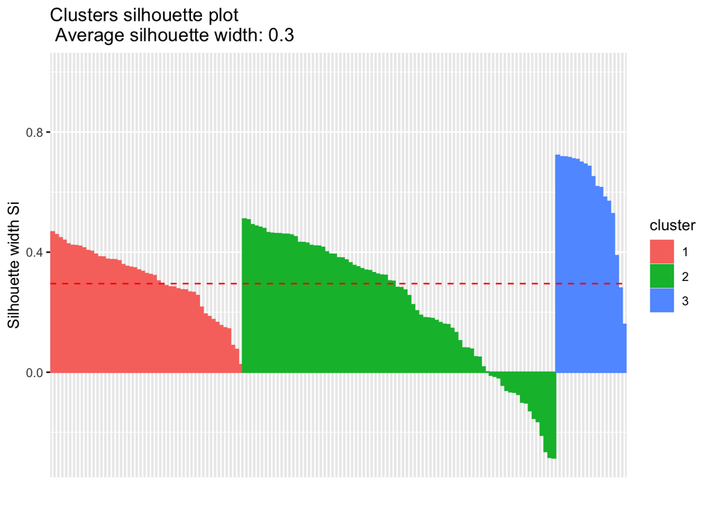

4. Si se mantiene pedir tres clusters en ambos procedimientos ¿ Cuántos países de los mal clusterizados k-medoides nos quedaría si no contásemos los mal clusterizados por jerarquizacion aglomerativa?

```
## [1] 6
```

5. Si usamos *dbscan*, ¿Cuántos clusters se formarían si usamos un epsilon de 0.09?

```
## dbscan Pts=147 MinPts=11 eps=0.09
##         0   1  2
## border 16  24  4
## seed    0  92 11
## total  16 116 15
```

6. Si usamos *dbscan*, ¿Qué países no fueron clusterizados (atípicos)?

```
##  [1] "Afghanistan"              "Bahrain"
##  [3] "Bhutan"                   "Burundi"
##  [5] "Central African Republic" "Chad"
##  [7] "Hong Kong"                "Kuwait"
##  [9] "Laos"                     "Malta"
## [11] "Qatar"                    "Rwanda"
## [13] "Singapore"                "Syria"
## [15] "United Arab Emirates"     "Uzbekistan"
```

7. ¿Qué paises coinciden entre los atipicos de *dbscan* y los mal clusterizados por jerarquizacion aglomerativa:

```
## [1] "Kuwait"
```

8. ¿Hay alguno de los países del cluster más bajo calculado con agnes que sea parte de los países difíciles de clusterizar en las *dbscan*?

```
##   agnes       GDP   Social   Healthy   Freedom Generosity Perceptions
## 1     1 0.7116531 1.053367 0.5618367 0.3354490  0.1837347   0.1096531
## 2     2 0.9247125 1.248975 0.7709000 0.3961750  0.1648625   0.0673375
## 3     3 1.4092222 1.515000 1.0260556 0.5494444  0.2821111   0.3077778
##   Electoral Functio-ning Politicalpartici-pation Politicalculture
## 1  1.806122     2.358980                3.525510         4.594286
## 2  7.946875     5.782125                5.917250         5.635500
## 3  9.096111     8.537222                7.931667         8.612778
##   Civilliberties
## 1       2.953265
## 2       6.996500
## 3       9.282222
```

```
##  [1] "Afghanistan"              "Bahrain"
##  [3] "Burundi"                  "Central African Republic"
##  [5] "Chad"                     "Laos"
##  [7] "Qatar"                    "Rwanda"
##  [9] "Syria"                    "United Arab Emirates"
## [11] "Uzbekistan"
```